# Assignment 13

Brian Roepkee

Dec 6, 2020

# Sentiment Analysis

Sentiment analysis of Twitter Data..

## Load Libraries and Data

```r
# twitter library
library(rtweet)

# plotting and pipes
library(tidyverse)
library(ggplot2)
library(dplyr)
library(stringr)
library(tidyr)
library(ggthemes)

# text mining library
library(tm)
library(tidytext)
library(wordcloud)
library(reshape2)
library(textstem)
library(ggraph)
library(igraph)
library(widyr)

# date/time library
library(lubridate)
```

```r
df <- read_twitter_csv("bots.csv")
```

```r
# Convert the date field to a datetime
df$created_at <- as_datetime(df$created_at)

#Changed some fields to factors for easier manipulation later
df$user_id <- as.factor(df$user_id)
df$status_id <- as.factor(df$status_id)
df$screen_name <- as.factor(df$screen_name)

# Fix up the reply count field.  It should be a int and NAs set to 0
df$reply_count[is.na(df$reply_count)] <- 0
df$reply_count <- as.integer(df$reply_count)
```

```r
head(df)
```

| user_id | status_id | created_at | screen_name | text | source | display_text_width | reply_to_status_id | reply_to_user_id | reply_to_screen_name | is_quote | is_retweet | favorite_count | retweet_count | quote_count | reply_count | hashtags | symbols | urls_url | urls_t.co | urls_expanded_url | media_url | media_t.co | media_expanded_url | media_type | ext_media_url | ext_media_t.co | ext_media_expanded_url | ext_media_type | mentions_user_id | … |
| --- | --- | --- | --- | --- | --- | --- | --- | --- | --- | --- | --- | --- | --- | --- | --- | --- | --- | --- | --- | --- | --- | --- | --- | --- | --- | --- | --- | --- | --- | --- |
| 1275656772460691458 | 1335333061626490880 | 2020-12-05 21:19:45 | AnibalLemus13 | Tenes razón ojalá que traiga audífonos. https://t.co/eFsZaTioiE | Twitter for Android | 39 | NA | NA | NA | TRUE | FALSE | 2 | 0 | NA | 0 | NA | NA | twitter.com/petrossof/stat… | https://t.co/eFsZaTioiE | https://twitter.com/petrossof/status/1335262596325384193 | NA | NA | NA | NA | NA | NA | NA | NA | NA | … |
| 1275656772460691458 | 1335329052467503105 | 2020-12-05 21:03:49 | AnibalLemus13 | @JulioIzquierd0 Mas falso que @BerenDagor \U0001f923 | Twitter for Android | 27 | 1335263825302605829 | 2390019062 | JulioIzquierd0 | FALSE | FALSE | 1 | 0 | NA | 0 | NA | NA | NA | NA | NA | NA | NA | NA | NA | NA | NA | NA | NA | 2390019062 1125843130421534720 | … |
| 1275656772460691458 | 1335320745308692480 | 2020-12-05 20:30:49 | AnibalLemus13 | Busquets anda repartiendo leña\nYa le perdonaron dos. | Twitter for Android | 52 | NA | NA | NA | FALSE | FALSE | 0 | 0 | NA | 0 | NA | NA | NA | NA | NA | NA | NA | NA | NA | NA | NA | NA | NA | NA | … |
| 1275656772460691458 | 1335311486705549312 | 2020-12-05 19:54:01 | AnibalLemus13 | @HoracioRubio97 @carrillorodas @realDonaldTrump Maga 2024 https://t.co/wFW2zKsx1O | Twitter for Android | 9 | 1335251326167560192 | 1031991161148321792 | HoracioRubio97 | FALSE | FALSE | 0 | 0 | NA | 0 | NA | NA | NA | NA | NA | http://pbs.twimg.com/media/Eof6tySUcAAUWqg.jpg | https://t.co/wFW2zKsx1O | https://twitter.com/AnibalLemus13/status/1335311486705549312/photo/1 | photo | http://pbs.twimg.com/media/Eof6tySUcAAUWqg.jpg | https://t.co/wFW2zKsx1O | https://twitter.com/AnibalLemus13/status/1335311486705549312/photo/1 | NA | 1031991161148321792 822294164872265730 25073877 | … |
| 1275656772460691458 | 1335310853483053057 | 2020-12-05 19:51:31 | AnibalLemus13 | @PCampoll @Santa_Pastelera https://t.co/Dg1dX9BfaP | Twitter for Android | 0 | 1335294374213771265 | 2165187725 | PCampoll | FALSE | FALSE | 0 | 0 | NA | 0 | NA | NA | NA | NA | NA | http://pbs.twimg.com/tweet_video_thumb/Eof6I_3UYAAMAhV.jpg | https://t.co/Dg1dX9BfaP | https://twitter.com/AnibalLemus13/status/1335310853483053057/photo/1 | photo | http://pbs.twimg.com/tweet_video_thumb/Eof6I_3UYAAMAhV.jpg | https://t.co/Dg1dX9BfaP | https://twitter.com/AnibalLemus13/status/1335310853483053057/photo/1 | NA | 2165187725 870321534287695872 | … |
| 1275656772460691458 | 1335309030500155393 | 2020-12-05 19:44:16 | AnibalLemus13 | @FranceliaSolanP Si fuera una casa privada lo entiendo poquito más pero es una colonia, no estaba entrando a la fuerza a su casa.\nPienso que hay culpa en ambos lados pero no fue para tanta soberbia d… | Twitter for Android | 195 | 1335065370017878016 | 1158785338644619265 | FranceliaSolanP | FALSE | FALSE | 0 | 0 | NA | 0 | NA | NA | NA | NA | NA | NA | NA | NA | NA | NA | NA | NA | NA | 1158785338644619265 | … |

```r
tail(df)
```

| user_id | status_id | created_at | screen_name | text | source | display_text_width | reply_to_status_id | reply_to_user_id | reply_to_screen_name | is_quote | is_retweet | favorite_count | retweet_count | quote_count | reply_count | hashtags | symbols | urls_url | urls_t.co | urls_expanded_url | media_url | media_t.co | media_expanded_url | media_type | ext_media_url | ext_media_t.co | ext_media_expanded_url | ext_media_type | mentions_user_id | … |
| --- | --- | --- | --- | --- | --- | --- | --- | --- | --- | --- | --- | --- | --- | --- | --- | --- | --- | --- | --- | --- | --- | --- | --- | --- | --- | --- | --- | --- | --- | --- |
| 1332969135504990209 | 1334998853649461250 | 2020-12-04 23:11:44 | Jasmin46706327 | @Gravitational @JasminNTaylor2 @AmyFaithLanc1 @AlexDasPferd @JoeBiden lol not a bot but i wass deleted cuz people cant handle my bold language or truths. but I am back now. needed a break fm this netw… | Twitter Web App | 141 | 1325922560308088835 | 15820272 | Gravitational | FALSE | FALSE | 0 | 0 | NA | 0 | NA | NA | NA | NA | NA | NA | NA | NA | NA | NA | NA | NA | NA | 15820272 1301747035511513088 825398600649863170 1180614073190363136 939091 | … |
| 1332969135504990209 | 1334998318535995392 | 2020-12-04 23:09:36 | Jasmin46706327 | lmfao i had to make a new account cuz mine got suspended but wtf is this crap. lmfao get over yourself. I am not a fuckin bot. im a free loving Trump supporting American and honestly i could give two … | Twitter Web App | 277 | NA | NA | NA | TRUE | FALSE | 0 | 0 | NA | 0 | NA | NA | twitter.com/Crazy4Chis/sta… | https://t.co/h28EOUy508 | https://twitter.com/Crazy4Chis/status/1323269535068229634 | NA | NA | NA | NA | NA | NA | NA | NA | NA | … |
| 1332969135504990209 | 1332974956687155200 | 2020-11-29 09:09:29 | Jasmin46706327 | Grizzly Adams, "wannabe biker dude" shatters the MASKER paradigm!! https://t.co/M07vLSa3UC | Twitter Web App | 110 | NA | NA | NA | FALSE | TRUE | 0 | 277 | NA | 0 | NA | NA | NA | NA | NA | http://pbs.twimg.com/ext_tw_video_thumb/1331705739577094149/pu/img/BdVMUxTljUF-U9OO.jpg | https://t.co/M07vLSa3UC | https://twitter.com/HighImpactFlix/status/1331706242511892481/video/1 | photo | http://pbs.twimg.com/ext_tw_video_thumb/1331705739577094149/pu/img/BdVMUxTljUF-U9OO.jpg | https://t.co/M07vLSa3UC | https://twitter.com/HighImpactFlix/status/1331706242511892481/video/1 | NA | 2899862569 | … |
| 1332969135504990209 | 1332974186810073088 | 2020-11-29 09:06:26 | Jasmin46706327 | Kary Mullis died on Aug. 7, 2019. A little over 2 months BEFORE Event 201. His PCR test went on to be used (abused?) to establish the "case counts" that are being used to fan the flames of FEAR and in… | Twitter Web App | 139 | NA | NA | NA | FALSE | TRUE | 0 | 171 | NA | 0 | NA | NA | NA | NA | NA | NA | NA | NA | NA | NA | NA | NA | NA | 2899862569 | … |
| 1332969135504990209 | 1332973788099612673 | 2020-11-29 09:04:51 | Jasmin46706327 | CONvid-1984: the only thing in the universe...\n\nWEAK enough to affect almost NO ONE... \n\n... yet POPULAR enough to destroy almost EVERYONE. \n\nThanks Corporate Fear-Porn Media!! | Twitter Web App | 140 | NA | NA | NA | FALSE | TRUE | 0 | 116 | NA | 0 | NA | NA | NA | NA | NA | NA | NA | NA | NA | NA | NA | NA | NA | 2899862569 | … |
| 1332969135504990209 | 1332971923056148480 | 2020-11-29 08:57:26 | Jasmin46706327 | @KamalaHarris These democrats better pray there is no such thing as hell, for if there is, they are all going there! | Twitter Web App | 134 | NA | NA | NA | FALSE | TRUE | 0 | 16 | NA | 0 | NA | NA | NA | NA | NA | NA | NA | NA | NA | NA | NA | NA | NA | 3242789798 30354991 | … |

### Filter out Retweets

Validate the number of rows before and after removing retweets.

```r
nrow(df)
```

```
## [1] 15072
```

```r
df <- df %>%
  filter(is_retweet == FALSE)
head(df)
```

| user_id | status_id | created_at | screen_name | text | source | display_text_width | reply_to_status_id | reply_to_user_id | reply_to_screen_name | is_quote | is_retweet | favorite_count | retweet_count | quote_count | reply_count | hashtags | symbols | urls_url | urls_t.co | urls_expanded_url | media_url | media_t.co | media_expanded_url | media_type | ext_media_url | ext_media_t.co | ext_media_expanded_url | ext_media_type | mentions_user_id | … |
| --- | --- | --- | --- | --- | --- | --- | --- | --- | --- | --- | --- | --- | --- | --- | --- | --- | --- | --- | --- | --- | --- | --- | --- | --- | --- | --- | --- | --- | --- | --- |
| 1275656772460691458 | 1335333061626490880 | 2020-12-05 21:19:45 | AnibalLemus13 | Tenes razón ojalá que traiga audífonos. https://t.co/eFsZaTioiE | Twitter for Android | 39 | NA | NA | NA | TRUE | FALSE | 2 | 0 | NA | 0 | NA | NA | twitter.com/petrossof/stat… | https://t.co/eFsZaTioiE | https://twitter.com/petrossof/status/1335262596325384193 | NA | NA | NA | NA | NA | NA | NA | NA | NA | … |
| 1275656772460691458 | 1335329052467503105 | 2020-12-05 21:03:49 | AnibalLemus13 | @JulioIzquierd0 Mas falso que @BerenDagor \U0001f923 | Twitter for Android | 27 | 1335263825302605829 | 2390019062 | JulioIzquierd0 | FALSE | FALSE | 1 | 0 | NA | 0 | NA | NA | NA | NA | NA | NA | NA | NA | NA | NA | NA | NA | NA | 2390019062 1125843130421534720 | … |
| 1275656772460691458 | 1335320745308692480 | 2020-12-05 20:30:49 | AnibalLemus13 | Busquets anda repartiendo leña\nYa le perdonaron dos. | Twitter for Android | 52 | NA | NA | NA | FALSE | FALSE | 0 | 0 | NA | 0 | NA | NA | NA | NA | NA | NA | NA | NA | NA | NA | NA | NA | NA | NA | … |
| 1275656772460691458 | 1335311486705549312 | 2020-12-05 19:54:01 | AnibalLemus13 | @HoracioRubio97 @carrillorodas @realDonaldTrump Maga 2024 https://t.co/wFW2zKsx1O | Twitter for Android | 9 | 1335251326167560192 | 1031991161148321792 | HoracioRubio97 | FALSE | FALSE | 0 | 0 | NA | 0 | NA | NA | NA | NA | NA | http://pbs.twimg.com/media/Eof6tySUcAAUWqg.jpg | https://t.co/wFW2zKsx1O | https://twitter.com/AnibalLemus13/status/1335311486705549312/photo/1 | photo | http://pbs.twimg.com/media/Eof6tySUcAAUWqg.jpg | https://t.co/wFW2zKsx1O | https://twitter.com/AnibalLemus13/status/1335311486705549312/photo/1 | NA | 1031991161148321792 822294164872265730 25073877 | … |
| 1275656772460691458 | 1335310853483053057 | 2020-12-05 19:51:31 | AnibalLemus13 | @PCampoll @Santa_Pastelera https://t.co/Dg1dX9BfaP | Twitter for Android | 0 | 1335294374213771265 | 2165187725 | PCampoll | FALSE | FALSE | 0 | 0 | NA | 0 | NA | NA | NA | NA | NA | http://pbs.twimg.com/tweet_video_thumb/Eof6I_3UYAAMAhV.jpg | https://t.co/Dg1dX9BfaP | https://twitter.com/AnibalLemus13/status/1335310853483053057/photo/1 | photo | http://pbs.twimg.com/tweet_video_thumb/Eof6I_3UYAAMAhV.jpg | https://t.co/Dg1dX9BfaP | https://twitter.com/AnibalLemus13/status/1335310853483053057/photo/1 | NA | 2165187725 870321534287695872 | … |
| 1275656772460691458 | 1335309030500155393 | 2020-12-05 19:44:16 | AnibalLemus13 | @FranceliaSolanP Si fuera una casa privada lo entiendo poquito más pero es una colonia, no estaba entrando a la fuerza a su casa.\nPienso que hay culpa en ambos lados pero no fue para tanta soberbia d… | Twitter for Android | 195 | 1335065370017878016 | 1158785338644619265 | FranceliaSolanP | FALSE | FALSE | 0 | 0 | NA | 0 | NA | NA | NA | NA | NA | NA | NA | NA | NA | NA | NA | NA | NA | 1158785338644619265 | … |

Show the total number of rows in this dataset.

```r
nrow(df)
```

```
## [1] 12968
```

### Add Doc_Id incrementing per Row

```r
df = df %>%
  mutate(doc_id = paste0("doc", row_number())) %>%
  select(doc_id, everything())
head(df)
```

| doc_id | user_id | status_id | created_at | screen_name | text | source | display_text_width | reply_to_status_id | reply_to_user_id | reply_to_screen_name | is_quote | is_retweet | favorite_count | retweet_count | quote_count | reply_count | hashtags | symbols | urls_url | urls_t.co | urls_expanded_url | media_url | media_t.co | media_expanded_url | media_type | ext_media_url | ext_media_t.co | ext_media_expanded_url | ext_media_type | … |
| --- | --- | --- | --- | --- | --- | --- | --- | --- | --- | --- | --- | --- | --- | --- | --- | --- | --- | --- | --- | --- | --- | --- | --- | --- | --- | --- | --- | --- | --- | --- |
| doc1 | 1275656772460691458 | 1335333061626490880 | 2020-12-05 21:19:45 | AnibalLemus13 | Tenes razón ojalá que traiga audífonos. https://t.co/eFsZaTioiE | Twitter for Android | 39 | NA | NA | NA | TRUE | FALSE | 2 | 0 | NA | 0 | NA | NA | twitter.com/petrossof/stat… | https://t.co/eFsZaTioiE | https://twitter.com/petrossof/status/1335262596325384193 | NA | NA | NA | NA | NA | NA | NA | NA | … |
| doc2 | 1275656772460691458 | 1335329052467503105 | 2020-12-05 21:03:49 | AnibalLemus13 | @JulioIzquierd0 Mas falso que @BerenDagor \U0001f923 | Twitter for Android | 27 | 1335263825302605829 | 2390019062 | JulioIzquierd0 | FALSE | FALSE | 1 | 0 | NA | 0 | NA | NA | NA | NA | NA | NA | NA | NA | NA | NA | NA | NA | NA | … |
| doc3 | 1275656772460691458 | 1335320745308692480 | 2020-12-05 20:30:49 | AnibalLemus13 | Busquets anda repartiendo leña\nYa le perdonaron dos. | Twitter for Android | 52 | NA | NA | NA | FALSE | FALSE | 0 | 0 | NA | 0 | NA | NA | NA | NA | NA | NA | NA | NA | NA | NA | NA | NA | NA | … |
| doc4 | 1275656772460691458 | 1335311486705549312 | 2020-12-05 19:54:01 | AnibalLemus13 | @HoracioRubio97 @carrillorodas @realDonaldTrump Maga 2024 https://t.co/wFW2zKsx1O | Twitter for Android | 9 | 1335251326167560192 | 1031991161148321792 | HoracioRubio97 | FALSE | FALSE | 0 | 0 | NA | 0 | NA | NA | NA | NA | NA | http://pbs.twimg.com/media/Eof6tySUcAAUWqg.jpg | https://t.co/wFW2zKsx1O | https://twitter.com/AnibalLemus13/status/1335311486705549312/photo/1 | photo | http://pbs.twimg.com/media/Eof6tySUcAAUWqg.jpg | https://t.co/wFW2zKsx1O | https://twitter.com/AnibalLemus13/status/1335311486705549312/photo/1 | NA | … |
| doc5 | 1275656772460691458 | 1335310853483053057 | 2020-12-05 19:51:31 | AnibalLemus13 | @PCampoll @Santa_Pastelera https://t.co/Dg1dX9BfaP | Twitter for Android | 0 | 1335294374213771265 | 2165187725 | PCampoll | FALSE | FALSE | 0 | 0 | NA | 0 | NA | NA | NA | NA | NA | http://pbs.twimg.com/tweet_video_thumb/Eof6I_3UYAAMAhV.jpg | https://t.co/Dg1dX9BfaP | https://twitter.com/AnibalLemus13/status/1335310853483053057/photo/1 | photo | http://pbs.twimg.com/tweet_video_thumb/Eof6I_3UYAAMAhV.jpg | https://t.co/Dg1dX9BfaP | https://twitter.com/AnibalLemus13/status/1335310853483053057/photo/1 | NA | … |
| doc6 | 1275656772460691458 | 1335309030500155393 | 2020-12-05 19:44:16 | AnibalLemus13 | @FranceliaSolanP Si fuera una casa privada lo entiendo poquito más pero es una colonia, no estaba entrando a la fuerza a su casa.\nPienso que hay culpa en ambos lados pero no fue para tanta soberbia d… | Twitter for Android | 195 | 1335065370017878016 | 1158785338644619265 | FranceliaSolanP | FALSE | FALSE | 0 | 0 | NA | 0 | NA | NA | NA | NA | NA | NA | NA | NA | NA | NA | NA | NA | NA | … |

### Add a Column for Text Length

```r
df$text_len <- str_count(df$text)
```

# EDA

Simplify the Data Frame to just the target fields we’ll be using throughout the analysis.

```r
df_select <- df %>%
  select(doc_id, user_id, status_id, screen_name, created_at, text, text_len)
```

## Tweet Length

```r
summary(df_select)
```

```
##     doc_id                         user_id                    status_id
##  Length:12968       1258164115022868480:  100   1260761154458054657:    1
##  Class :character   1260823480473436160:  100   1265479452869275653:    1
##  Mode  :character   1262141055471718400:  100   1265479804255531008:    1
##                     1265289477171236865:  100   1266784624601993216:    1
##                     1268976130209402880:  100   1267237936589754368:    1
##                     1269773684518146052:  100   1267504813274574848:    1
##                     (Other)            :12368   (Other)            :12962
##          screen_name      created_at                      text
##  _okayshane    :  100   Min.   :2020-05-14 02:37:37   Length:12968
##  50shousewife7 :  100   1st Qu.:2020-11-18 00:37:01   Class :character
##  BananaUgly1   :  100   Median :2020-12-01 04:32:22   Mode  :character
##  Beantwn2      :  100   Mean   :2020-11-22 10:35:45
##  BoardofBologna:  100   3rd Qu.:2020-12-04 18:12:31
##  buaku5        :  100   Max.   :2020-12-05 22:03:27
##  (Other)       :12368
##     text_len
##  Min.   :  1.0
##  1st Qu.: 51.0
##  Median : 92.0
##  Mean   :120.3
##  3rd Qu.:174.0
##  Max.   :824.0
##
```

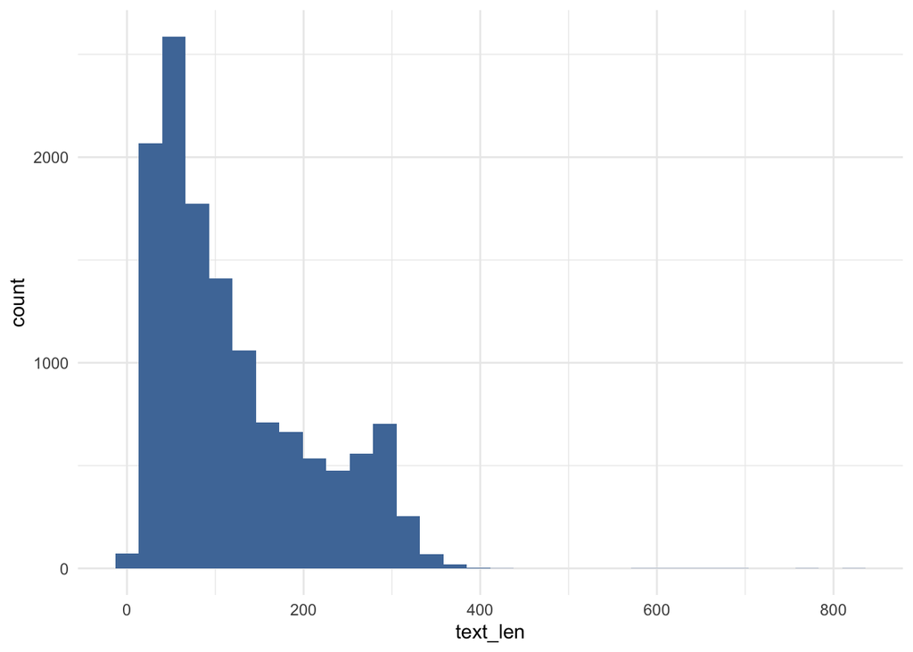

```r
df_select %>%
  ggplot(aes(x = text_len, fill="#1F77B4")) +
  geom_histogram(bins = 32, show.legend = FALSE) +
  theme_minimal() +
  scale_fill_tableau()
```

### Tweets Over Time

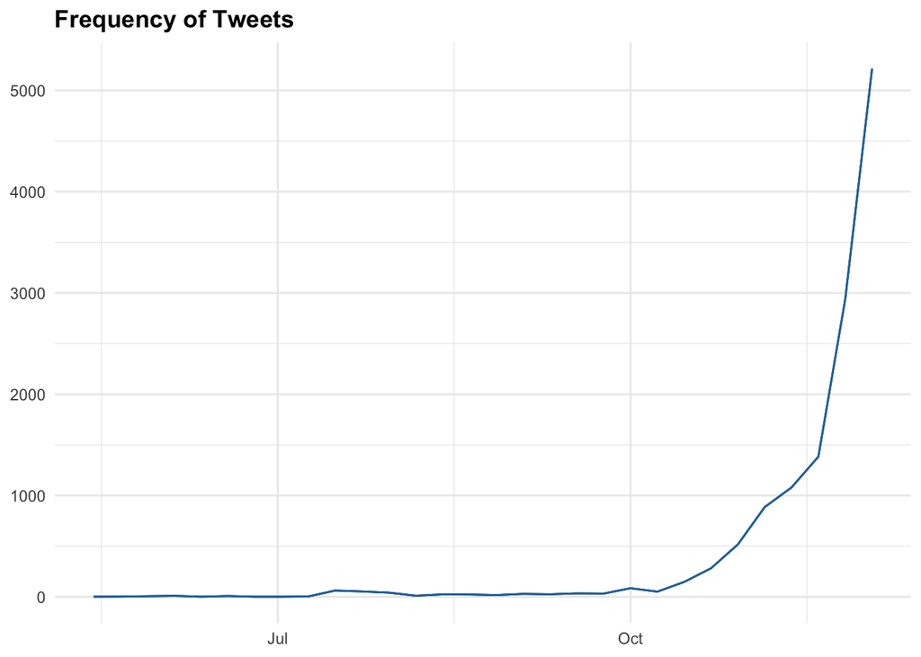

```r
df_select %>%
  ts_plot("1 weeks", trim = 0L) +
  geom_line(color = "#1F77B4") +
  theme_minimal() +
  scale_fill_tableau() +
  theme(
    legend.title = element_blank(),
    legend.position = "right",
    plot.title = element_text(face = "bold")) +
  labs(
    x = NULL, y = NULL,
    title = "Frequency of Tweets"
  )
```

# Clean and Prepare the Text for Analysis

Get rid of various useless text like URLS and shortened URLs. These appear frequently in the text and skew results.

### Clean Twitter specific items

https://stackoverflow.com/questions/31348453/how-do-i-clean-twitter-data-in-r

```r
df_select$text = gsub("[ \t]{2,}", " ", df_select$text)
df_select$text = gsub("http\\t.c+", " ", df_select$text)
df_select$text = gsub("(RT|via)((?:\\b\\W*@\\w+)+)", "", df_select$text)
df_select$text = gsub("@\\w+", " ", df_select$text)
df_select$text = gsub("http[[:alnum:][:punct:]]*", " ", df_select$text)
df_select$text = gsub("^\\s+|\\s+$", " ", df_select$text)
df_select$text = gsub("[[:digit:]]", " ", df_select$text)
df_select$text <- str_replace_all(df_select$text," "," ")
df_select$text <- str_replace(df_select$text,"RT @[a-z,A-Z]*: ","")
df_select$text <- str_replace_all(df_select$text,"#[a-z,A-Z]*","")
df_select$text <- str_replace_all(df_select$text,"@[a-z,A-Z]*","")
# Non Latin Characters
df_select$text <- iconv(df_select$text, "latin1", "ASCII", sub = "")
# New Lines
df_select$text <- str_replace_all(df_select$text,"\\n","")
df_select$text <- str_replace_all(df_select$text,'\"',"")
# Ampersands
df_select$text <- gsub("&amp", "", df_select$text)
```

### Remove Whitespace and Lemmatize

```r
df_select$text = stripWhitespace(df_select$text)
df_select$text = lemmatize_strings(df_select$text)
```

```r
tail(df_select$text, n=10)
```

```
##  [1] ". Muppet family."
##  [2] "but can you read? must watch? wtf? go away."
##  [3] "DACA, defer Action For Childhood Arrival ) in case you care. Somalia, Afghanistan, Iran, WTF Jared in Israel. Now million in donation to challenge the election go to a fund that Trump can take as salary. What be wrong with you f * * * republican?"
##  [4] "Biden be not the winner.. he be a cheater!!!!!"
##  [5] "I do believe it either. the rally trump be so big in Cali. I only know a few who vote Biden; the amount of people know who vote Trump be real. I do trust it. I mean look one who rule here n harris be fm here, as good as nancy. We need a whole new election."
##  [6] "It use to be beautiful, Newsom have destroy it along with his aunt. Many of us vote against them. We do not like Nancy u moron."
##  [7] "U be a fuckin moron. No one enjoy live in ca. high homeless, high tax, shitty ass live environment, country's bad govern. U must be high or some shit. I've live in Cali my whole life and I hate it nowadays. No one wish they can live in this shit hole....."
##  [8] "I hope ur not serious!!! so u like the fact people r lose their life for a virus with a. % survival rate."
##  [9] "lol not a bot but i be delete cuz people cant handle my bold language or truth. but I be back now. need a break fm this network anyways"
## [10] "lmfao i have to make a new account cuz mine get suspend but wtf be this crap. lmfao get over yourself. I be not a fuckin bot. im a free love Trump support American and honestly i can give two fuck if you believe me or not. i do owe u people shit. ignorant ass people"
```

### Unnest_Tokens()

Create a new column with each word on it’s own row.

```r
tidy_df <- df_select %>%
  unnest_tokens(word, text)
```

### Stop Word Removal

remove stop words and custom stop words from the results.

Note: Removing Trump because it’s a proper name but also an verb which was marked as positive and appeared in the top results for both candidates.

```r
custom_stop_words <- bind_rows(tibble(word = c("trump"), lexicon = c("custom")), stop_words)

tidy_df <- tidy_df %>%
  anti_join(custom_stop_words, by = "word")
```

### Validate the New number of Rows

Dramatically larger now that each word from text is in it’s own row.

```r
nrow(tidy_df)
```

```
## [1] 79808
```

# Sentiment Analysis

## Bing Sentiment Lexicon

Using the Bing Lexicon from Bing Liu and collaborators, adds the column “Sentiment” and mark each word as positive or negative.

https://www.cs.uic.edu/~liub/FBS/sentiment-analysis.html

```r
bing_df <- tidy_df %>%
  inner_join(get_sentiments("bing"), by = "word")
```

```r
bing_df %>%
  group_by(sentiment) %>%
  summarise(count = n(), .groups = "keep")
```

| sentiment | count |
| --- | --- |
| negative | 10713 |
| positive | 4652 |

### AFINN scoring Lexicon

AFINN from Finn Årup Nielsen, adds the `value` column, with a numeric representation of how positive, or negative the word is. The AFINN lexicon measures sentiment with a numeric score between -5 and 5

http://www2.imm.dtu.dk/pubdb/pubs/6010-full.html

```r
afinn_df <- tidy_df %>%
  inner_join(get_sentiments("afinn"), by = "word")

head(afinn_df)
```

| doc_id | user_id | status_id | screen_name | created_at | text_len | word | value |
| --- | --- | --- | --- | --- | --- | --- | --- |
| doc33 | 1275656772460691458 | 1334720393622405126 | AnibalLemus13 | 2020-12-04 04:45:14 | 20 | true | 2 |
| doc37 | 1275656772460691458 | 1334693727810416640 | AnibalLemus13 | 2020-12-04 02:59:16 | 89 | powerful | 2 |
| doc43 | 1275656772460691458 | 1334572282874720257 | AnibalLemus13 | 2020-12-03 18:56:42 | 63 | dick | -4 |
| doc81 | 1275656772460691458 | 1333927504139096064 | AnibalLemus13 | 2020-12-02 00:14:34 | 33 | bitch | -5 |
| doc81 | 1275656772460691458 | 1333927504139096064 | AnibalLemus13 | 2020-12-02 00:14:34 | 33 | die | -3 |
| doc89 | 1275656772460691458 | 1333863838832156672 | AnibalLemus13 | 2020-12-01 20:01:35 | 60 | beautiful | 3 |

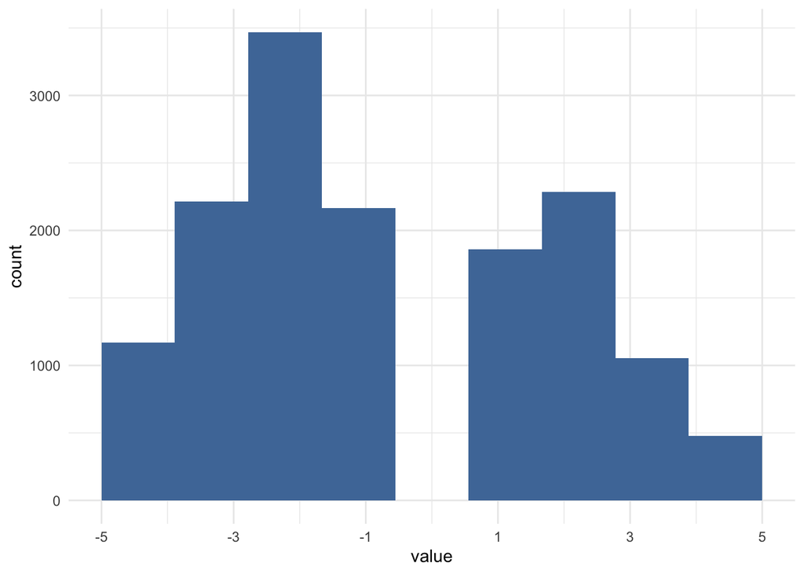

```r
afinn_df %>%
  ggplot(aes(x = value, fill="#1F77B4")) +
  geom_histogram(bins = 10, show.legend = FALSE) +
  scale_x_continuous(breaks = c(-5, -3, -1, 1, 3, 5)) +
  theme_minimal() +
  scale_fill_tableau()
```

*Note: `0` is not a valid value in this scoring system, therefore the bin is empty*

### NRC Sentiment Lexicon

NRC from Saif Mohammad and Peter Turney. The NRC Emotion Lexicon is a list of English words and their associations with eight basic emotions as well as positive and negative sentiment.

One thing to note, single words can have multiple emotions

```r
nrc_df <- tidy_df %>%
  inner_join(get_sentiments("nrc"), by = "word")
```

Total counts for all 8 emotions and 2 sentiments.

```r
nrc_df %>%
  group_by(sentiment) %>%
  summarise(total = n(), .groups = "keep") %>%
  arrange(desc(total))
```

| sentiment | total |
| --- | --- |
| negative | 12505 |
| positive | 11952 |
| trust | 8733 |
| fear | 6786 |
| anticipation | 6270 |
| anger | 6155 |
| sadness | 5597 |
| joy | 4630 |
| disgust | 4467 |
| surprise | 3053 |

### Top Word Counts (BING)

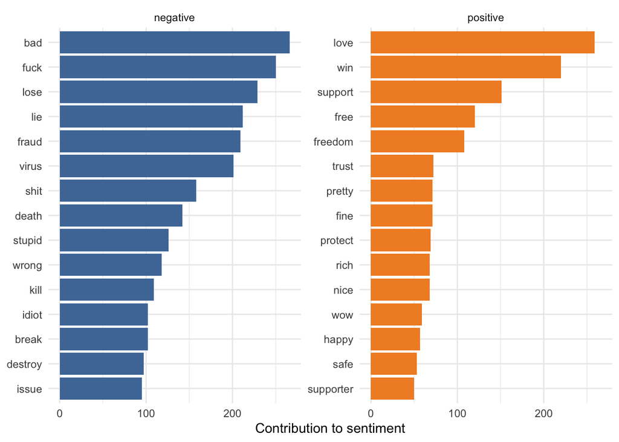

```r
bing_df %>%
  count(word, sort = TRUE, sentiment) %>%

  group_by(sentiment) %>%
  top_n(15) %>%
  ungroup() %>%
  mutate(word = reorder(word, n)) %>%
  ggplot(aes(n, word, fill = sentiment)) +
  geom_col(show.legend = FALSE) +
  facet_wrap(~sentiment, scales = "free_y") +
  theme_minimal() +
  scale_fill_tableau() +
  labs(x = "Contribution to sentiment",
       y = NULL)
```

### Overall Top Words (BING)

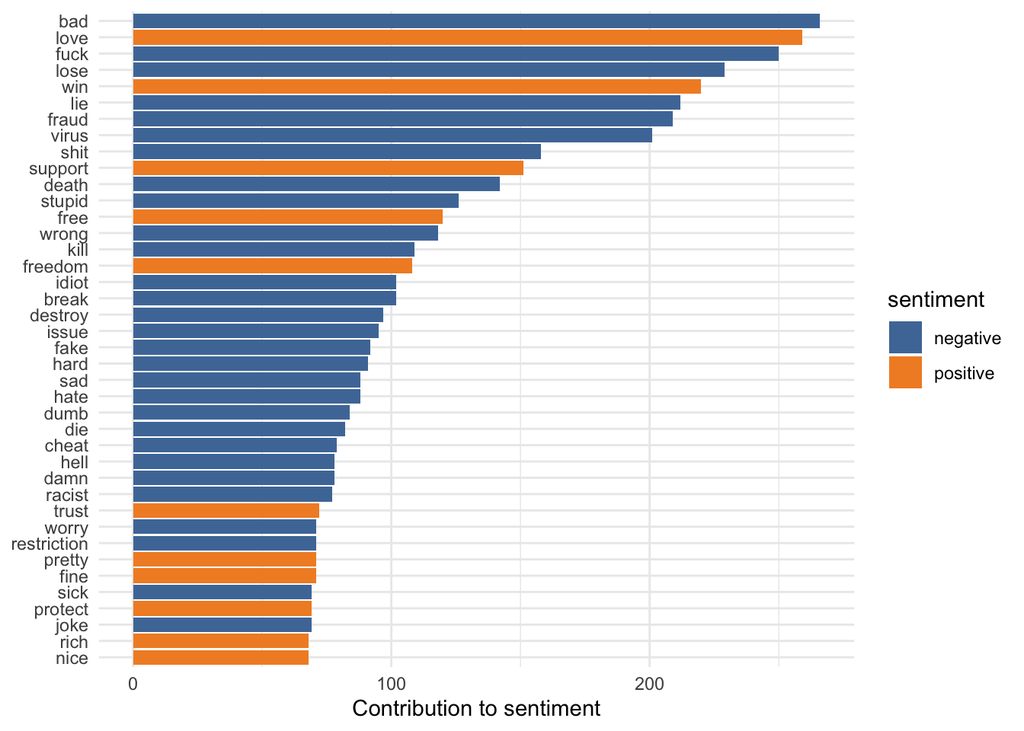

```r
bing_df %>%
  count(word, sort = TRUE, sentiment) %>%
  top_n(40) %>%
  ungroup() %>%
  mutate(word = reorder(word, n)) %>%
  ggplot(aes(n, word, fill = sentiment)) +
  geom_col(show.legend = TRUE) +
  theme_minimal() +
  scale_fill_tableau() +
  labs(x = "Contribution to sentiment", y = NULL)
```

### Top Words Sorted by AFINN Score

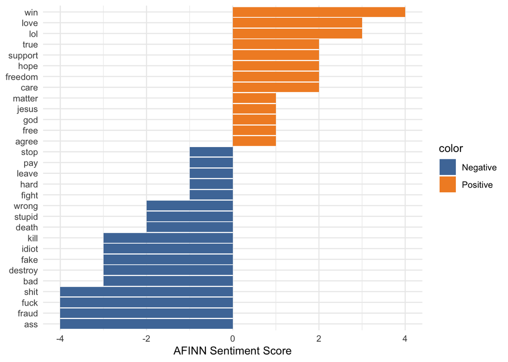

```r
afinn_df$color <- ifelse(afinn_df$value < 0, "Negative","Positive")

afinn_df %>%
  count(word, sort = TRUE, value, color) %>%
  top_n(30) %>%
  ungroup() %>%
  mutate(word = reorder(word, value)) %>%

  ggplot(aes(value, word, fill = color)) +
  geom_col(show.legend = TRUE) +
  theme_minimal() +
  scale_fill_tableau() +
  labs(x = "AFINN Sentiment Score", y = NULL)
```

### Sentiment of Tweets over Time (AFINN)

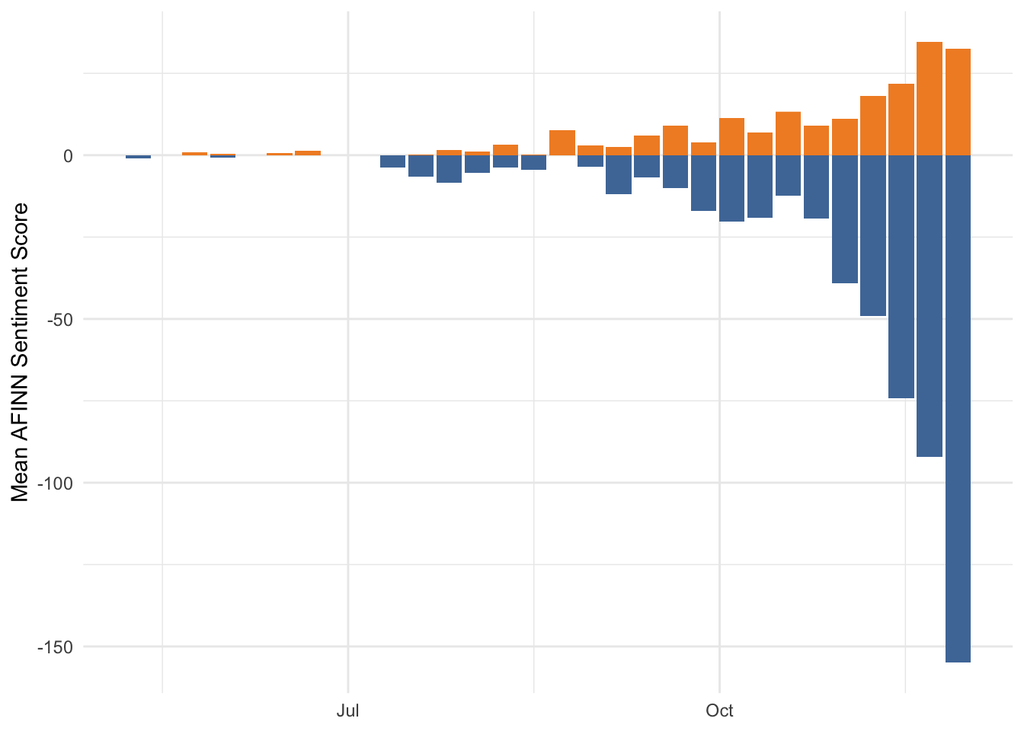

```r
plot_df2 <- afinn_df %>%
  mutate(mon = floor_date(created_at, "1 week")) %>%
  group_by(screen_name, mon) %>%
  summarize(value = mean(value), .groups = 'keep')

plot_df2$color <- ifelse(plot_df2$value < 0, "negative","positive")

ggplot(plot_df2, aes(mon, value, fill = color)) +
  geom_col(show.legend = FALSE) +
  labs(x = NULL, y = "Mean AFINN Sentiment Score") +
  theme_minimal() +
  scale_fill_tableau()
```

## Most Positive Messages

```r
afinn_df %>%
  group_by(doc_id) %>%
  summarize(total_value = sum(value), word_count = n(), .groups = "keep") %>%
  arrange(desc(total_value)) %>%
  head()
```

| doc_id | total_value | word_count |
| --- | --- | --- |
| doc6458 | 16 | 8 |
| doc7806 | 14 | 4 |
| doc9199 | 13 | 5 |
| doc6440 | 12 | 6 |
| doc1694 | 11 | 6 |
| doc2640 | 11 | 4 |

```r
df %>%
  filter(doc_id == "doc6458" | doc_id == "doc7806" | doc_id == "doc9199") %>%
  select(text)
```

| text |
| --- |
| @tobykeith Yes LORD in all things give thanks and glory to GOD! God bless America, the Flag and All those serving this country, Men and Women! Safe and Happy Blessings to all! “Love one Another “ |
| @JoeBiden You know you are not gonna win. Let's be honest for a min. If you got the vote, the swamp would've parade your winning results so fast it will make your head spin. Because you didn't win the… |
| Happy Thanksgiving To My Twitter Fam! \U0001f983\U0001f341\U0001f37d \n\nIm thankful for each and every one of you following me on this financial journey. \n\nCount your blessings today, be thankful f… |

## Most Negative Messages

```r
afinn_df %>%
  group_by(doc_id) %>%
  summarize(total_value = sum(value), word_count = n(), .groups = "keep") %>%
  arrange(total_value) %>%
  head()
```

| doc_id | total_value | word_count |
| --- | --- | --- |
| doc3517 | -25 | 9 |
| doc2020 | -23 | 7 |
| doc12965 | -22 | 8 |
| doc9511 | -22 | 8 |
| doc11988 | -21 | 6 |
| doc12069 | -21 | 7 |

```r
df %>%
  filter(doc_id == "doc3517" | doc_id == "doc2020" | doc_id == "doc12965") %>%
  select(text)
```

| text |
| --- |
| Holy hell!!??!? How can Creepy Joe offer Embassador to the United Nations too a treasonous Criminal that had her people smash phones drill holes in them B4 handing over to The FBI? OMG if that SLIMEY … |
| @tomselliott @JohnBrennan Do use all a favor and shut your lying ass mouth. It’s fuckin clear you do nothing but try n blow smoke up the american ppls asses. 80 million Americans are not as dumb as u … |
| @3amwithgab @GrahamDorsey5 U are a fuckin moron. No one enjoys living in ca. Highest homeless, highest taxes, shitty ass living environments, country's worst govern. U must be high or some shit. I've … |

# Word Clouds

## Overall Word Cloud

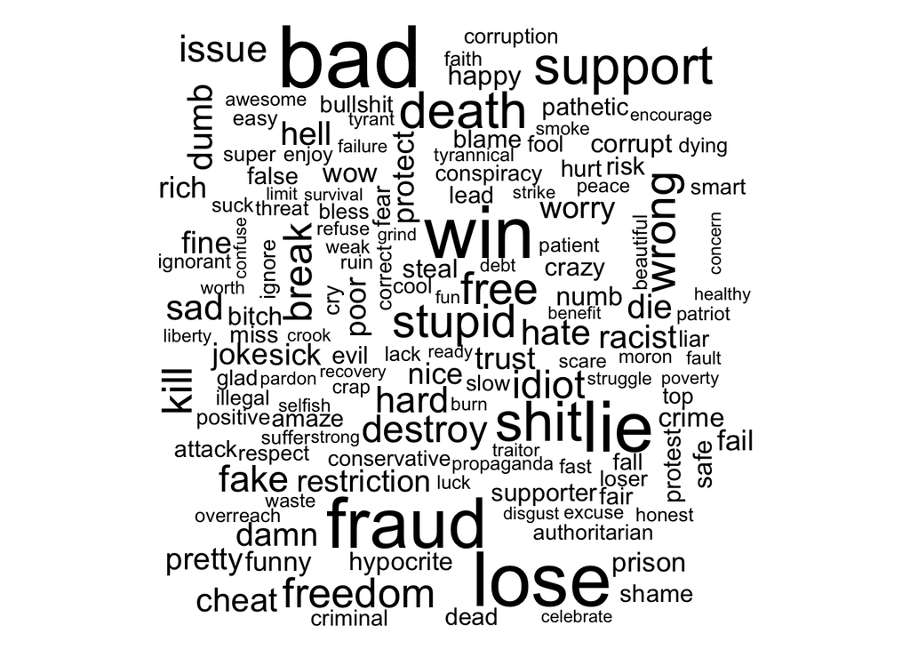

```r
bing_df %>%
  count(word) %>%
  with(wordcloud(word, n, max.words = 150))
```

## By Sentiment

Word cloud of the top 200 words grouped by sentiment, positive or negative.

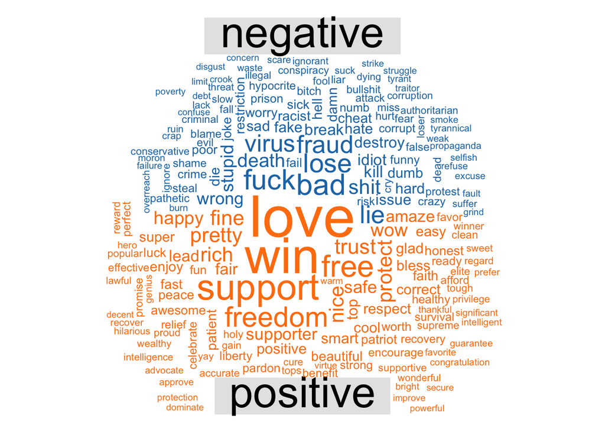

```r
bing_df %>%
  count(word, sentiment, sort = TRUE) %>%
  acast(word ~ sentiment, value.var = "n", fill = 0) %>%
  comparison.cloud(colors = c("#1F77b4", "#FF7F0E"), max.words = 200)
```

# Checking for Top-Negation Word Pairs

The method used here doesn’t take into account negation of words like no, and never preceding words. We can quckly check the top word pairs to see how they occur in our text.

```r
df_select$text <- removeWords(df_select$text, c(stopwords('english'), "i"))
```

```r
bigrams <- df_select %>%
  unnest_tokens(bigram, text, token = "ngrams", n = 2)
```

```r
bigram_counts <- bigrams %>%
  count(bigram, sort = TRUE) %>%
  separate(bigram, c("word1", "word2"), sep = " ")

head(bigram_counts, n=10)
```

| word1 | word2 | n |
| --- | --- | --- |
| NA | NA | 2018 |
| i | think | 166 |
| wear | mask | 111 |
| i | know | 107 |
| i | can | 74 |
| i | hope | 69 |
| we | need | 67 |
| right | now | 66 |
| stimulus | check | 65 |
| look | like | 64 |

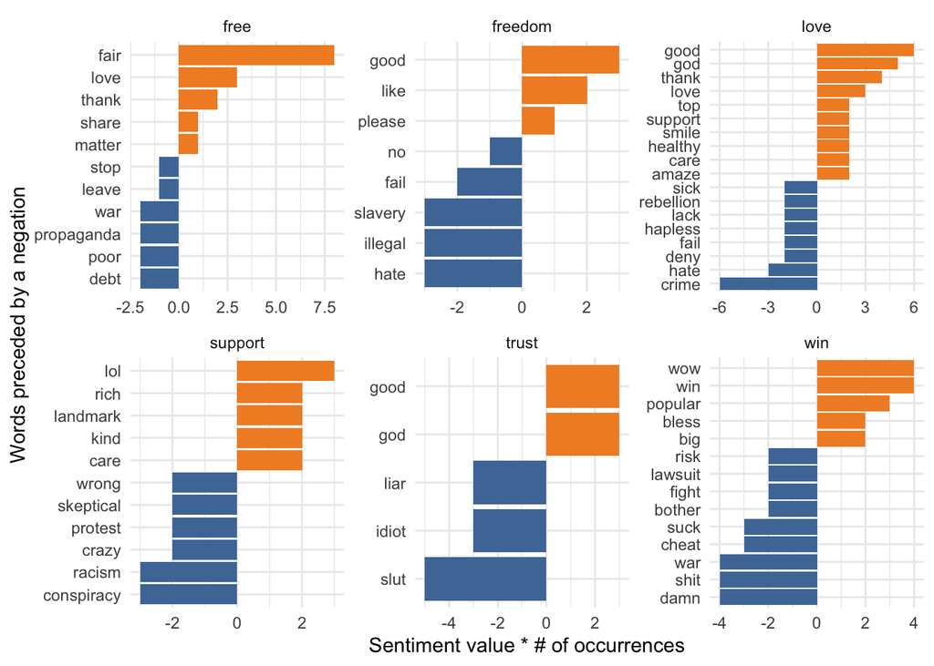

```r
negate_words <- c("love", "support", "free", "freedom", "win", "trust")


bigram_counts %>%
  filter(word1 %in% negate_words) %>%
  count(word1, word2, wt = n, sort = TRUE) %>%
  inner_join(get_sentiments("afinn"), by = c(word2 = "word")) %>%
  mutate(contribution = value * n) %>%
  group_by(word1) %>%
  slice_max(abs(contribution), n = 10) %>%
  ungroup() %>%
  mutate(word2 = reorder_within(word2, contribution, word1)) %>%

  ggplot(aes(contribution, word2, fill = contribution > 0)) +
  geom_col(show.legend = FALSE) +
  facet_wrap(~word1, scales = "free", nrow = 2) +
  scale_y_reordered() +
  theme_minimal() +
  scale_fill_tableau() +
  labs(x = "Sentiment value * # of occurrences",
       y = "Words preceded by a negation")
```

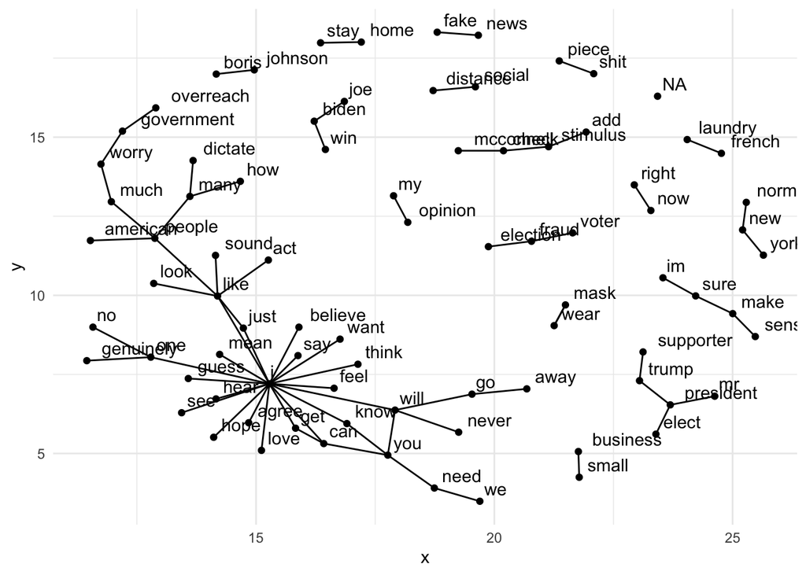

```r
bigram_graph <- bigram_counts %>%
  filter(n > 25) %>%
  graph_from_data_frame()

set.seed(2017)

ggraph(bigram_graph, layout = "fr") +
  geom_edge_link() +
  geom_node_point() +
  geom_node_text(aes(label = name), vjust = -.5, hjust = -.2) +
  theme_minimal() +
  scale_fill_tableau()
```